# R Notebook

# third predictor

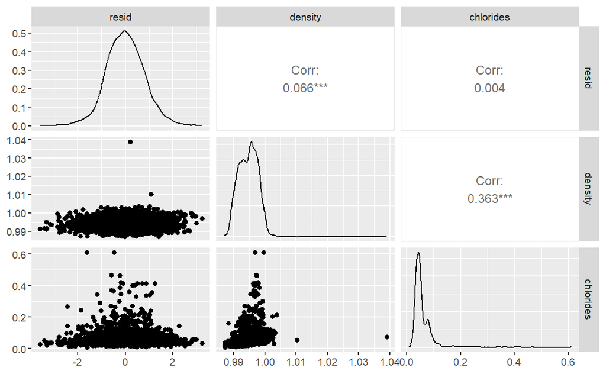

```r
wine_resid2 <- wine_quality_combined %>%
  add_residuals(model2a, var = "resid") %>%
  select(resid, density, chlorides)

wine_resid2 %>%
  ggpairs(progress = FALSE)
```

```r
model3a <- lm(quality ~ alcohol + volatile_acidity + chlorides, data = wine_quality_combined)
model3b <- lm(quality ~ alcohol + volatile_acidity + density, data = wine_quality_combined)
```

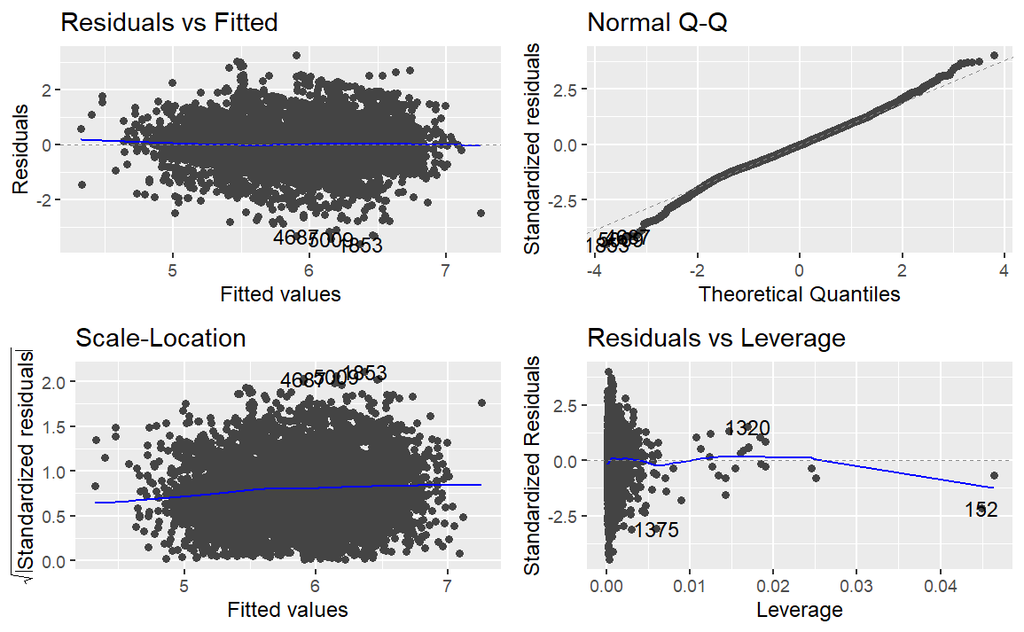

```r
# model3a <- lm(quality ~ alcohol + volatile_acidity + chlorides, data = wine_quality_combined)

autoplot(model3a)
```

```r
# residuals look consisten,
# data normally distributed
# low heteroscedasticity

summary(model3a)
```

```
Call:
lm(formula = quality ~ alcohol + volatile_acidity + chlorides,
    data = wine_quality_combined)

Residuals:
    Min      1Q  Median      3Q     Max
-3.6078 -0.5237 -0.0098  0.5184  3.2451

Coefficients:
                  Estimate Std. Error t value Pr(>|t|)
(Intercept)       2.872877   0.097681  29.411   <2e-16 ***
alcohol           0.325809   0.008703  37.436   <2e-16 ***
volatile_acidity -1.336067   0.065792 -20.307   <2e-16 ***
chlorides         0.123093   0.319694   0.385      0.7
---
Signif. codes:  0 ‘***’ 0.001 ‘**’ 0.01 ‘*’ 0.05 ‘.’ 0.1 ‘ ’ 1

Residual standard error: 0.8068 on 6493 degrees of freedom
Multiple R-squared:  0.2389,    Adjusted R-squared:  0.2386
F-statistic: 679.5 on 3 and 6493 DF,  p-value: < 2.2e-16
```

```r
# adj r2 is 0.2386 but effect not signifcant
```

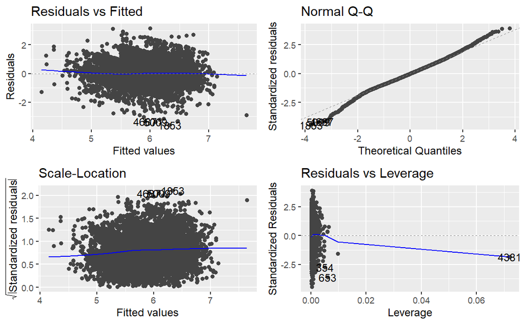

```r
# model3b <- lm(quality ~ alcohol + volatile_acidity + density, data = wine_quality_combined)

autoplot(model3b)
```

```r
# residuals look consistent,
# data normally distributed
# low heteroscedasticity

summary(model3b)
```

```
Call:
lm(formula = quality ~ alcohol + volatile_acidity + density,
    data = wine_quality_combined)

Residuals:
    Min      1Q  Median      3Q     Max
-3.5752 -0.5229 -0.0111  0.5116  3.1498

Coefficients:
                  Estimate Std. Error t value Pr(>|t|)
(Intercept)      -35.51606    4.91103  -7.232 5.31e-13 ***
alcohol            0.38963    0.01176  33.130  < 2e-16 ***
volatile_acidity  -1.49647    0.06434 -23.257  < 2e-16 ***
density           37.98219    4.85653   7.821 6.08e-15 ***
---
Signif. codes:  0 ‘***’ 0.001 ‘**’ 0.01 ‘*’ 0.05 ‘.’ 0.1 ‘ ’ 1

Residual standard error: 0.803 on 6493 degrees of freedom
Multiple R-squared:  0.246, Adjusted R-squared:  0.2457
F-statistic: 706.3 on 3 and 6493 DF,  p-value: < 2.2e-16
```

```r
# adj r2 is 0.2457 , effect of density is signifcant
```

```r
anova(model2a, model3b)
```

```
Analysis of Variance Table

Model 1: quality ~ alcohol + volatile_acidity
Model 2: quality ~ alcohol + volatile_acidity + density
  Res.Df    RSS Df Sum of Sq      F    Pr(>F)
1   6494 4226.4
2   6493 4186.9  1    39.442 61.166 6.082e-15 ***
---
Signif. codes:  0 ‘***’ 0.001 ‘**’ 0.01 ‘*’ 0.05 ‘.’ 0.1 ‘ ’ 1
```

# remaining predictors

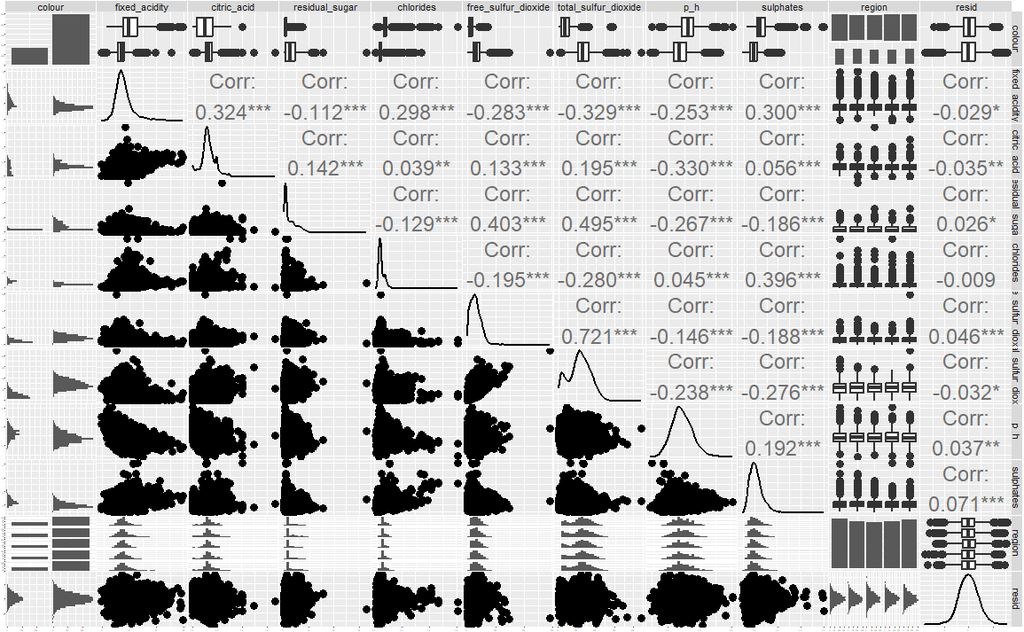

## Model Interpretation

The quality rating of wine is affected by the alcohol concentration, volatile_acidity + density.

for a wine with density alcohol % of 4, volatile_acidity of 0.7 and density of 0.98,

quality = -35.51606 + 0.38 * alcohol + -1.49647 * volatile_acidity + 37.98219 * density quality = -35.51606 + 4 * 0.38 + -1.49647 * 0.7 + 37.98219 * 0.98 quality = 2.178957

Note: from homework answers it is important to remove variables that are highly correlated with each other. In this instance it would have been important to drop density as this is highly correlated with alcohol content.